# Autoencoder

```python
import numpy as np
from typing import List, Tuple
from numpy.typing import ArrayLike
from nn import NeuralNetwork, one_hot_encode_seqs, sample_seqs
from sklearn import datasets
from sklearn.model_selection import train_test_split,KFold
import pandas as pd
import matplotlib.pyplot as plt
```

### 5-fold CV Grid Search to find optimal NN architecture

- 5-fold Grid search CV was implemented manually to find optimal architecture (i.e, # of layers) hyperparameter
- Data was split into train and test set. Test set was completely held out for the grid search CV; grid search hyperparameter tuning was done using only the training data.

```python
## load and split data into train and test set. test set will be completely held out
# of grid search via cross validation.
np.random.seed(42)
digits = datasets.load_digits()
X = digits['data']
y = digits['target'] #just including this here for train_test_split, but not using it
X_train, X_test, y_train, y_test = train_test_split(X, y, test_size=0.33, random_state=42)


# perform Grid search via cross validation on the training data
#training data will be split into train and validation set, while the original
#test set is held out

#saving the average MSE across all epochs in each fold with each combination of proposed
#hyperparameters
columns = ["size","avg_train_error","avg_val_error"] + [f"train_error_fold_{x}" for x in range(1,6)] \
         + [f"val_error_fold_{x}" for x in range(1,6)]
tuning_results_df = pd.DataFrame(columns = columns)


sizes = {2:
       [{'input_dim': 64, 'output_dim': 16, 'activation': 'relu'},
       {'input_dim': 16, 'output_dim': 64, 'activation': 'relu'}],

       4:
        [{'input_dim': 64, 'output_dim': 32, 'activation': 'relu'},
       {'input_dim': 32, 'output_dim': 16, 'activation': 'relu'},
       {'input_dim': 16, 'output_dim': 32, 'activation': 'relu'},
       {'input_dim': 32, 'output_dim': 64, 'activation': 'relu'}],

         6:
          [{'input_dim': 64, 'output_dim': 48, 'activation': 'relu'},
       {'input_dim': 48, 'output_dim': 32, 'activation': 'relu'},
       {'input_dim': 32, 'output_dim': 16, 'activation': 'relu'},
       {'input_dim': 16, 'output_dim': 32, 'activation': 'relu'},
       {'input_dim': 32, 'output_dim': 48, 'activation': 'relu'},
       {'input_dim': 48, 'output_dim': 64, 'activation': 'relu'}]}








kf = KFold(n_splits=5)
df_idx = 0
for size in sizes:
    print(size)
    fold_avg_train_losses = []
    fold_avg_val_losses = []
    for fold_idx, (train,val) in enumerate(kf.split(X_train,y_train)):
        fold_idx = fold_idx + 1


        # fit NN using current architecture size (i.e, 2 layers, 4 layers, etc)
        # using stochastic gradient descent
        nn = NeuralNetwork(nn_arch=sizes[size],
                       lr=0.001, batch_size=200, seed=42, epochs=5000,
                        loss_function='mean_squared_error')
        #fit this fold. test data is still held out
        train_loss, val_loss = nn.fit(X_train[train],X_train[train],
                                       X_train[val],X_train[val])
        fold_avg_train_loss = np.mean(train_loss) #avg (across epochs) training loss for this fold
        fold_avg_train_losses.append(fold_avg_train_loss)

        fold_avg_val_loss = np.mean(val_loss) #avg (across epochs) validation loss for this fold
        fold_avg_val_losses.append(fold_avg_val_loss)


        #store hyperparameters and per-fold results
        tuning_results_df.loc[df_idx,"size"]=size
        tuning_results_df.loc[df_idx,f"train_error_fold_{fold_idx}"] = fold_avg_train_loss
        tuning_results_df.loc[df_idx,f"val_error_fold_{fold_idx}"] = fold_avg_val_loss

    #store average train and val loss across all folds for this combination of hyperparameters
    tuning_results_df.loc[df_idx,"avg_train_error"] = np.mean(fold_avg_train_losses)
    tuning_results_df.loc[df_idx,"avg_val_error"] = np.mean(fold_avg_val_losses)

    df_idx +=1
```

```
2
4
6
```

```python
#resulting dataframe stores error from each fold with each combination of hyperparameters
#as well as the average error across all 5 folds with each combnation of hyperparameters
display(tuning_results_df)
```

|  | size | avg_train_error | avg_val_error | train_error_fold_1 | train_error_fold_2 | train_error_fold_3 | train_error_fold_4 | train_error_fold_5 | val_error_fold_1 | val_error_fold_2 | val_error_fold_3 | val_error_fold_4 | val_error_fold_5 |
| --- | --- | --- | --- | --- | --- | --- | --- | --- | --- | --- | --- | --- | --- |
| 0 | 2 | 4.337328 | 4.408944 | 4.217549 | 4.532941 | 4.239629 | 4.50061 | 4.195909 | 4.246691 | 4.432037 | 4.484903 | 4.543029 | 4.33806 |
| 1 | 4 | 9.573355 | 9.623124 | 9.614036 | 9.987455 | 9.391221 | 9.479837 | 9.394224 | 9.530214 | 9.930968 | 9.694307 | 9.558571 | 9.401559 |
| 2 | 6 | 9.720596 | 9.780699 | 9.795357 | 9.635501 | 9.720041 | 9.688594 | 9.763488 | 9.763264 | 9.610833 | 9.783694 | 9.76918 | 9.976528 |

```python
#get data for combination of hyperparameters that gave the lowest average MSE
# across epochs and folds in the validation set
display(tuning_results_df.loc[tuning_results_df['avg_val_error'].astype(float).idxmin()])
best_nn_size = tuning_results_df.loc[tuning_results_df['avg_val_error'].astype(float).idxmin(),'size']

print(f"The optimal neural network had {best_nn_size} layers")
```

```
size                         2
avg_train_error       4.337328
avg_val_error         4.408944
train_error_fold_1    4.217549
train_error_fold_2    4.532941
train_error_fold_3    4.239629
train_error_fold_4     4.50061
train_error_fold_5    4.195909
val_error_fold_1      4.246691
val_error_fold_2      4.432037
val_error_fold_3      4.484903
val_error_fold_4      4.543029
val_error_fold_5       4.33806
Name: 0, dtype: object
```

```
The optimal neural network had 2 layers
```

### Re-training model with optimal hyperparameters and plotting per-epoch train and test MSE

- I tuned the architecture (i.e # of layers) hyperparameter of the neural network by implementing a cross-validated grid search; the size of the NN that minimized the average across-fold MSE was used moving forward. A subset of samples were completely held out from this procedure to be used for validation/testing here.
  - I chose my hyperparameters using a grid search. Grid search tuning suggested the autencoder with 2 total layers (rather than one with 4 or 6 layers) performed the best. Therefore, I proceeded with using a 2 layer autoencoder.
  - Other possible hyperparameters (i.e, learning rate) were not considered to minimize computing time, and because i hypothesized that NN architecture would play a bigger role in the autoencoder performance relative to a choice of many reasonable learning rates.
- These results suggest the model was able to learn from the training data, as the training loss decreased as the number of epochs increased.

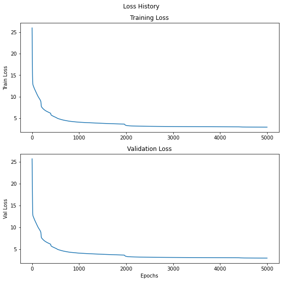

```python
nn = NeuralNetwork(nn_arch = sizes[best_nn_size],
                       lr=0.001, batch_size=200, seed=42, epochs=5000,
                        loss_function='mean_squared_error')

#X_train contain the same observations that were used for cross validation grid search
#X_test was completely held out of the grid search procedure
per_epoch_train_loss, per_epoch_val_loss = nn.fit(X_train,X_train,
                                               X_test,X_test)



loss_hist = per_epoch_train_loss
loss_hist_val = per_epoch_val_loss
assert len(loss_hist) > 0, "Need to run training before plotting loss history"
fig, axs = plt.subplots(2, figsize=(8,8))
fig.suptitle('Loss History')
axs[0].plot(np.arange(len(loss_hist)), loss_hist)
axs[0].set_title('Training Loss')
axs[1].plot(np.arange(len(loss_hist_val)), loss_hist_val)
axs[1].set_title('Validation Loss')
plt.xlabel('Epochs')
axs[0].set_ylabel('Train Loss')
axs[1].set_ylabel('Val Loss')
fig.tight_layout()
plt.show()
```

### Average reconstruction error over held out test dataset

- Take trained model and form predictions on entire datase then calculate MSE across the held out test dataset

```python
#average MSE from unseen test data
test_predictions = nn.predict(X_test)
test_reconstruction_error = nn._mean_squared_error(X_test,test_predictions)
print(f"Average reconstruction error over unseen test data {test_reconstruction_error}")
```

```
Average reconstruction error over unseen test data 2.9646700617603217
```

## Proof I was able to more-or-less reconstruct the images. Showing the first image in the held-out-test set as an exmaple

```
Prediction from first example in held-out test set
```

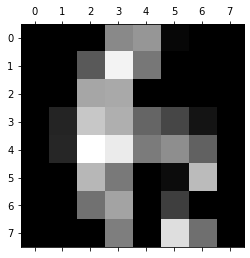

```
First example from held-out test set
```

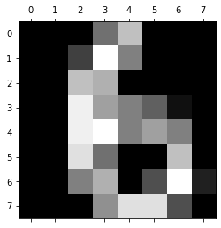

```python
plt.gray()
print("Prediction from first example in held-out test set")
plt.matshow(test_predictions[0].reshape(8,8))
plt.show()
print("First example from held-out test set")
plt.matshow(X_test[0].reshape(8,8))
plt.show()
```

# Conclusions

- Autoencoder was able to reconstruct images moderately well, as evidences through the low held-out test MSE and visually looking at the reconstruction of the images themselves.